# Análise da série: The Big Bang Theory

Lucas Magno

# Apresentação

The Big Bang Theory, frequentemente abreviada como “TBBT”, é uma série de televisão norte-americana de comédia de situação criada por Chuck Lorre e Bill Prady, que estreou no canal CBS em 24 de setembro de 2007.

Essa é uma Analise básica sobre a série.

Lista de episodios. É o primeiro passo para começar a analise

```r
episodios%>%
  select("Nome do episodio" = nome_episodio, "Temporada" = num_temporada, "Avaliação"= avaliacao_media)
```

| Nome do episodio | Temporada | Avaliação |
| --- | --- | --- |
| Pilot | 1 | 8.4 |
| The Big Bran Hypothesis | 1 | 8.5 |
| The Fuzzy Boots Corollary | 1 | 7.9 |
| The Luminous Fish Effect | 1 | 8.3 |
| The Hamburger Postulate | 1 | 8.1 |
| The Middle Earth Paradigm | 1 | 8.5 |
| The Loobenfeld Decay | 1 | 8.2 |
| The Pancake Batter Anomaly | 1 | 8.3 |
| The Jerusalem Duality | 1 | 8.1 |
| The Bat Jar Conjecture | 1 | 8.5 |

[output cut: 270 more lines]

# Popularidade dos episódios

Como será que é a votação dos episodios ?

Abaixo temos um grafico sobre isso

[figure not shown]

```r
ggplot(episodios, aes(num_votos)) +
  geom_histogram() +
  xlab("Avaliação dos Episodios") +
  ylab("Quantidade de Episodios")
```

## Quantas avaliações tem por episódio?

Podemos ver que geralmente os episodios tem 2.000 avaliações por episodio.

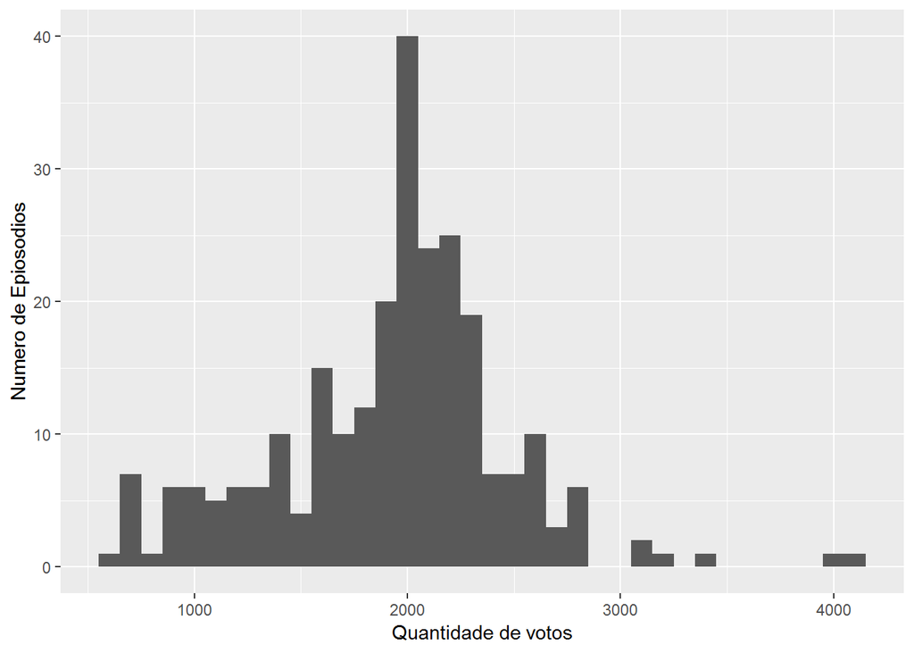

```r
ggplot(episodios, aes(num_votos))+
  geom_histogram(binwidth = 100)+
  xlab("Quantidade de votos")+
  ylab("Numero de Epiosodios")
```

## Qual o episódio mais popular e o menos popular?

Mais POPULAR É o primeiro epiosodio, da primeira temporada.

```r
episodios%>%
  top_n(1, num_votos)%>%
    select("Nome do episodio" = nome_episodio, "Temporada" = num_temporada, "Avaliação"= avaliacao_media)
```

| Nome do episodio | Temporada | Avaliação |
| --- | --- | --- |
| Pilot | 1 | 8.4 |

Menos POPULAR É o episodio 22 da temporada 11

```r
episodios%>%
  top_n(-1, num_votos)%>%
    select("Nome do episodio" = nome_episodio, "Temporada" = num_temporada, "Avaliação"= avaliacao_media)
```

| Nome do episodio | Temporada | Avaliação |
| --- | --- | --- |
| The Monetary Insufficiency | 11 | 7.3 |

## Qual a temporada mais popular e a menos popular?

Melhor Temporada A temporada mais popular geralmente é a que tem mais votos. E nesse caso foi a temporada:

```r
Temp_melhor <- episodios%>%
  group_by(num_temporada)%>%
  summarise(votos_temporada = mean(num_votos))%>%
  top_n(1, votos_temporada)
Temp_melhor
```

| num_temporada | votos_temporada |
| --- | --- |
| 1 | 2650.667 |

Pior temporada Enquanto a pior:

```r
Temp_melhor <- episodios%>%
  group_by(num_temporada)%>%
  summarise(votos_temporada = mean(num_votos))%>%
  top_n(-1, votos_temporada)
Temp_melhor
```

| num_temporada | votos_temporada |
| --- | --- |
| 11 | 900.75 |

# Qualidade dos episódios

## Qual a distribuição das avaliações por episódio?

Ná avaliação média, temos que geralmente os episodios recebem notas entra 8,1 e 8,4.

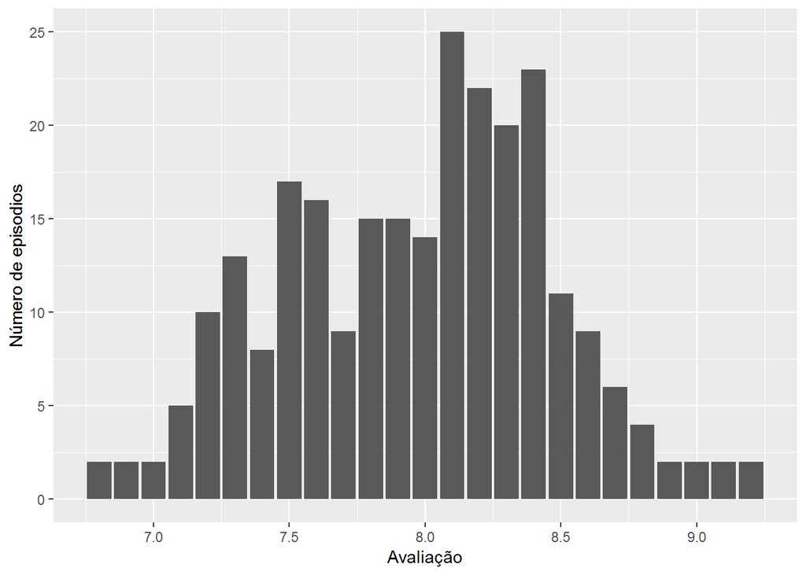

```r
ggplot(episodios, aes(avaliacao_media)) +
  geom_bar()+
  xlab("Avaliação")+
  ylab("Número de episodios")
```

## Qual o melhor e o pior episódio segundo o IMDB?

Melhor Episodio segundo o IMDB

Temos um empate com dois episodios com a melhor avaliação.

```r
Melhor_ep <- episodios%>%
  top_n(1,avaliacao_media)
Melhor_ep %>%
    select("Nome do episodio" = nome_episodio, "Temporada" = num_temporada, "Avaliação"= avaliacao_media)
```

| Nome do episodio | Temporada | Avaliação |
| --- | --- | --- |
| The Bath Item Gift Hypothesis | 2 | 9.2 |
| The Opening Night Excitation | 9 | 9.2 |

Podemos desempatar pelo número de votos, ou seja quem tiver mais números de votos fica em primeiro… E o resultado foi :

```r
  episodios %>%
   top_n(1, avaliacao_media) %>%
  top_n(1, num_votos)%>%
  select("Nome do episodio" = nome_episodio, "Temporada" = num_temporada)
```

| Nome do episodio | Temporada |
| --- | --- |
| The Bath Item Gift Hypothesis | 2 |

Pior episodio segundo o IMDB também temos 2 casos.

```r
Pior_ep <- episodios%>%
  top_n(-1,avaliacao_media)

Pior_ep%>%
    select("Nome do episodio" = nome_episodio, "Temporada" = num_temporada, "Avaliação"= avaliacao_media)
```

| Nome do episodio | Temporada | Avaliação |
| --- | --- | --- |
| The Matrimonial Momentum | 9 | 6.8 |
| The Cognition Regeneration | 10 | 6.8 |

```r
episodios%>%
  group_by(num_temporada)%>%
  summarise(media_votos=mean(num_votos))%>%
  top_n(1, media_votos)
```

| num_temporada | media_votos |
| --- | --- |
| 1 | 2650.667 |

Pior temporada

```r
episodios%>%
  group_by(num_temporada)%>%
  summarise(media_votos=mean(num_votos))%>%
  top_n(-1, media_votos)
```

| num_temporada | media_votos |
| --- | --- |
| 11 | 900.75 |

# Padrões ao longo do tempo

## As primeiras temporadas são melhores que as últimas?

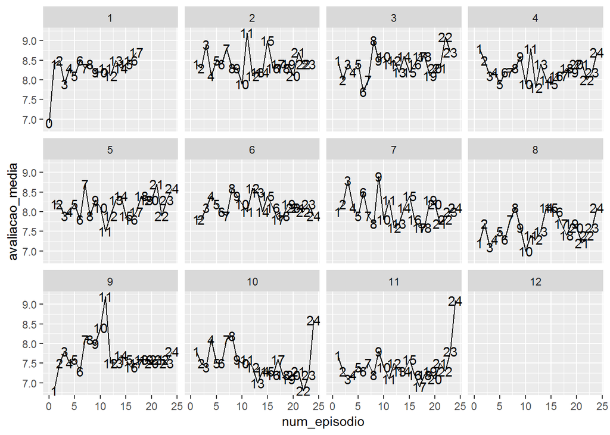

```r
ggplot(episodios, aes(num_episodio, avaliacao_media)) +
  geom_text(aes(label = num_episodio)) +
  geom_line() +
  facet_wrap(~ num_temporada)
```

## Qual é a temporada mais regular?

A temporada 6, nesse caso pode ser considerada a mais regular.

[figure not shown]

```r
episodios%>%
  ggplot(aes(num_temporada, avaliacao_media)) +
  geom_point() +
  geom_smooth() +
  xlab("Temporadas") +
  ylab("Número de votos")
```

## Qual é a temporada mais instável?

Pelo o gráfico acima temos que a temporada mais instavel é a 9.O grafico deixa isso bem claro na separação de suas avaliações.

# Valores incomuns

Sim. podemos ver isso nas temporadas: 1,9 e 11. São pontos bem afastados da curva.

## Existem episódios outliers em termos de popularidade?

Valores incomuns de número de votos em relação a outros episódios da série.

Sim, na temporada 11 como podemos ver tanto no gráfico quanto abaixo.

```r
episodios%>%
  top_n(-1, num_votos)%>%
    select("Nome do episodio" = nome_episodio, "Temporada" = num_temporada)
```

| Nome do episodio | Temporada |
| --- | --- |
| The Monetary Insufficiency | 11 |

## Existem episódios outliers em termos de avaliação?

Valores incomuns de avaliação em relação a outros episódios da série.

Os outliers são mais os da temporada 9 e 10.

```r
episodios%>%
  top_n(-1, avaliacao_media)%>%
    select("Nome do episodio" = nome_episodio, "Temporada" = num_temporada)
```

| Nome do episodio | Temporada |
| --- | --- |
| The Matrimonial Momentum | 9 |
| The Cognition Regeneration | 10 |